# Using the web to detect and predict spatial relationships

Emmanouil Tranos University of Bristol, School of Geographical Sciences; Alan Turing Institute [etranos.info](https://etranos.info/), [@EmmanouilTranos](https://twitter.com/EmmanouilTranos), e.tranos@bristol.ac.uk

## Main idea

- Limited capacity to observe **spatial relationships**
- *Tangible*:
  - Movements of individuals
  - Vehicle or passenger flows
- A lot of work lately (transport and mobility big data)
- Various challenges regarding scale, velocity etc.

## Main idea

- *Intangible*:
  - Trade between regions
  - Business relationships
  - Knowledge flows
  - Historical ties
  - Social ties
- Difficult to capture (surveys)
- **Important** for policy designing (e.g. transport infrastructure)

## Main idea

- Use the web to identify spatial relationships
- *Dependencies* between cities and regions
- Web text:
  - To detect and predict such relationships
  - Various spatial and temporal scales
  - *Contextualise* these relationships

# Why use the web?

## Web data and business studies

- Businesses may not expose all of their strategies on their websites, but neither do they do during surveys (Arora et al. 2013)
- Business websites:
  - spreading information
  - establishing a public image
  - supporting online transactions
  - sharing opinions

## Business studies using hyperlinks

- Hyperlinks to business websites reflect business motivations and contain useful business information (Vaughan, Gao, and Kipp 2006)
- Significant correlations between the number of incoming links and business performance (Vaughan 2004; Vaughan and Wu 2004)
- Krüger et al. (2020) used hyperlinks between business websites in Germany to test the role of different proximity frameworks
- Innovative businesses share more hyperlinks with other business, which also tend to be innovative

## Spatial studies using hyperlinks

- Hyperlinks tend to follow national borders and gravitate towards the US (Halavais 2000)
- Keßler (2017) used the hyperlinks between German Wikipedia webpages to represent the hierarchy of urban centres in Germany
- Salvini and Fabrikant (2016) used a the English Wikipedia to build a graph of world cities
- Hyperlinks between and to administrative websites to study spatial relationships and structure (Holmberg and Thelwall 2009; Holmberg 2010; Janc 2015)

## Spatial studies using hyperlinks

- Lin, Halavais, and Zhang (2007) used webblog hyperlinks to analyse the spatial reflections of the blogsphere
- Jones, Spigel, and Malecki (2010) focused on the New York City theatre scene to investigate the existence and role of a ‘virtual buzz’

# Our current work

- JISC UK Web Domain Dataset: .uk webpages in the Internet Archive 1996-2010
- Tranos and Stich (2020)
- Tranos, Kitsos, and Ortega-Argilés (2021)
- Tranos, Carrascal-Incera, and Willis (2020)

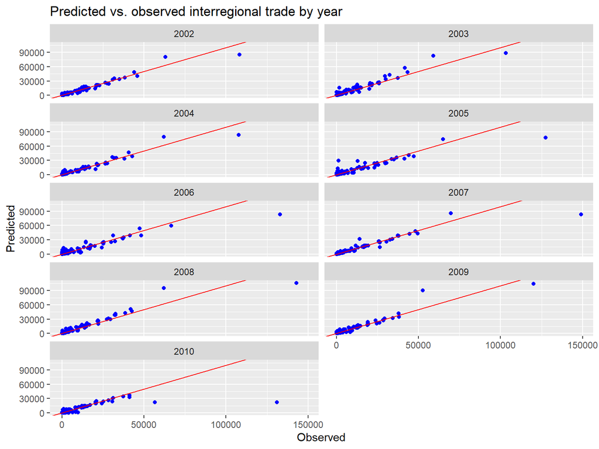

# Gap

- Importance of understanding spatial relationship for urban and regional policy making
- Some work on extracting spatial relations from the web
- Most of it is based hyperlinks between geolocated websites
- Limited work based on toponym co-occurrences (Meijers and Peris 2019)
- **Very limited** work on contextualisation of such relationships
- **Hardly any work** in utilising such data to create meaningful geographic knowledge
- Importance: inform city and regional **policies**

# The new PhD project

- ML, NLP statistical and network modelling
- Named entity recognition (actors, organisations, events, toponym disambiguation)
- Extract spatial relationships
- Contextualise (NLP)
- Multiscalar approach
- Spatio-temporal networks
- Need for methods incorporating space & text
- Tools to access large web archives

# The new PhD project

- Untapped potential to utilise the web as a data source
- Data science tools to support social science and policy making

# References

Arora, Sanjay K, Jan Youtie, Philip Shapira, Lidan Gao, and TingTing Ma. 2013. “Entry Strategies in an Emerging Technology: A Pilot Web-Based Study of Graphene Firms.” *Scientometrics* 95 (3): 1189–1207.

Halavais, Alexander. 2000. “National Borders on the World Wide Web.” *New Media & Society* 2 (1): 7–28.

Holmberg, Kim. 2010. “Co-Inlinking to a Municipal Web Space: A Webometric and Content Analysis.” *Scientometrics* 83 (3): 851–62.

Holmberg, Kim, and Mike Thelwall. 2009. “Local Government Web Sites in Finland: A Geographic and Webometric Analysis.” *Scientometrics* 79 (1): 157–69.

Janc, Krzysztof. 2015. “Geography of Hyperlinks—Spatial Dimensions of Local Government Websites.” *European Planning Studies* 23 (5): 1019–37.

Jones, Brant W, Ben Spigel, and Edward J Malecki. 2010. “Blog Links as Pipelines to Buzz Elsewhere: The Case of New York Theater Blogs.” *Environment and Planning B: Planning and Design* 37 (1): 99–111.

Keßler, Carsten. 2017. “Extracting Central Places from the Link Structure in Wikipedia.” *Transactions in GIS* 21 (3): 488–502.

Krüger, Miriam, Jan Kinne, David Lenz, and Bernd Resch. 2020. “The Digital Layer: How Innovative Firms Relate on the Web.” *ZEW-Centre for European Economic Research Discussion Paper*, nos. 20-003.

Lin, Jia, Alexander Halavais, and Bin Zhang. 2007. “The Blog Network in America: Blogs as Indicators of Relationships Among Us Cities.” *Connections* 27 (2): 15–23.

Meijers, Evert, and Antoine Peris. 2019. “Using Toponym Co-Occurrences to Measure Relationships Between Places: Review, Application and Evaluation.” *International Journal of Urban Sciences* 23 (2): 246–68.

Salvini, Marco M, and Sara I Fabrikant. 2016. “Spatialization of User-Generated Content to Uncover the Multirelational World City Network.” *Environment and Planning B: Planning and Design* 43 (1): 228–48.

Tranos, Emmanouil, Andre Carrascal-Incera, and George Willis. 2020. “Material and Immaterial Regional Interdependencies: Using the Web to Predict Regional Trade Flows.” *ERSA Conference*.

Tranos, Emmanouil, Tasos Kitsos, and Raquel Ortega-Argilés. 2021. “Digital Economy in the Uk: Regional Productivity Effects of Early Adoption.” *Regional Studies* in press.

Tranos, Emmanouil, and Chrisotph Stich. 2020. “Individual Internet Usage and the Availability of Online Content of Local Interest: A Multilevel Approach.” *Computers, Environment and Urban Systems* 79: 101371.

Vaughan, Liwen. 2004. “Exploring Website Features for Business Information.” *Scientometrics* 61 (3): 467–77.

Vaughan, Liwen, Yijun Gao, and Margaret Kipp. 2006. “Why Are Hyperlinks to Business Websites Created? A Content Analysis.” *Scientometrics* 67 (2): 291–300.

Vaughan, Liwen, and Guozhu Wu. 2004. “Links to Commercial Websites as a Source of Business Information.” *Scientometrics* 60 (3): 487–96.